# ANOVA

Esko

22.08.2016

In the following, we will demonstrate how you would calculate one way or two-way ANOVAs in R.

We will use the same game data as in the previous session.

```r
game.wmc <- read.table("kr_gamewmc.txt", header=T)
game.wmc$accuracy <- game.wmc$Phit + game.wmc$PcorrectRejection
```

Then we will investigate accuracy as a function of age group and gender.

Basically, because we are using a linear model, we can use function lm.

```r
# single main effect models
fm.a <- lm(accuracy ~ age_grp, game.wmc)
fm.g <- lm(accuracy ~ gender, game.wmc)

# both main effects
fm.ag <- lm(accuracy ~ age_grp + gender, game.wmc)

# main effects and interaction
fm.ag <- lm(accuracy ~ age_grp * gender, game.wmc)

# age_grp * gender a shorthand for writing
fm.ag2 <- lm(accuracy ~ age_grp + gender + age_grp:gender, game.wmc)
```

We could use function anova to compare the models, and then select what to choose. But what if we would like to get the F-values for effects, in the exactly same way as in SPSS?

We could write

```r
anova(fm.ag)
```

```
## Analysis of Variance Table
##
## Response: accuracy
##                Df   Sum Sq  Mean Sq F value    Pr(>F)
## age_grp         1 0.088479 0.088479 19.9270 9.363e-05 ***
## gender          1 0.005622 0.005622  1.2663    0.2688
## age_grp:gender  1 0.000287 0.000287  0.0646    0.8010
## Residuals      32 0.142086 0.004440
## ---
## Signif. codes:  0 '***' 0.001 '**' 0.01 '*' 0.05 '.' 0.1 ' ' 1
```

Unfortunately, this may not be what you wanted. Especially, the output is not the same as in SPSS by default.

## R’s anova calculates Type I Sum of Squares

R’s anova function give type I Sum of Squares, but SPSS tells us type III Sum of Squares by default. We can get type III Sum of Squares using function Anova from package car. I have deliberately decided not to show the example yet, because there is a high chance the output would be wrong, if you do not set the right contrasts.

## Why to use type III Sum of Squares?

If the data were balanced, both type I and III Sum of Squares would produce exactly the same results. However, then number of children is larger than the number of males, the proportion of females in adult is group is not the same as in the children group, etc.

```r
with(game.wmc, table(age_grp, gender))
```

```
##        gender
## age_grp Mies Nainen
##       A    3      7
##       C   15     11
```

*anova* function uses type I Sum of Squares. When the data is unbalanced, the order in which the predictors are included into the model matters, because the are evaluated *sequentially*. The first predictor explains all the variation it can, the second explains the portion of variance left over from the first predictor etc.

In the case of an unbalanced design, this amounts to comparing group means weighted by their individual sample sizes, which is something that the researcher is not usually interested in. For a fine discussion of these issues, see the [presentation by Zhan](http://md.psych.bio.uni-goettingen.de/mv/unit/lm_cat/InteractionsAndTypesOfSS.pdf).

In many cases, the resercher is interested in the unweighted means. That is, what is the effect after controlling for every other effect. In balanced designs, balancing ensures that we get the right results anyway, but with unbalanced design, we must use type III Sum of Squares to get the intended results.

Consequently, the rule of thumb is to ‘always’ use type III Sum of Squares, because it would work also with balanced designs.

## With type III Sum of Squares, you must you orthogonal contrasts

You may remember from the statistical courses that if you use type III Sum of Squares, you must use orthogonal contrasts. Otherwise your results may be wrong.

So what are orthogonal contrasts? First, analysis of variance can be tought as a linear model. When running a statistical test, the program estimates the parameters for each term in the model. Basically, constrasts define what does the parameter estimates in the fitted model mean. If the contrasts are not orthogonal, the procedure for calculating the type III Sum of Squares produces the wrong results.

*The catch is that by default, the contrasts in R are not orthogonal.*

You can check what are the current default contrasts. If you have not changed them, you will see that R uses treatment contrasts for unordered factors, and polynomous contrasts for ordered factors. The problem here is that treatment contrasts are not orthogonal.

```r
options("contrasts")

#$contrasts
#        unordered           ordered
#"contr.treatment"      "contr.poly"
```

You can set the default contrasts to be orthogonal like this.

```r
options(contrasts = c("contr.sum", "contr.poly"))

options("contrasts")
```

```
## $contrasts
## [1] "contr.sum"  "contr.poly"
```

Below, there is an example of how the contrasts setting affects the results.

```r
library(car) # load package car to get the function Anova

# This is right!
options(contrasts = c("contr.sum", "contr.poly"))
options("contrasts")
```

```
## $contrasts
## [1] "contr.sum"  "contr.poly"
```

```r
fm.ag <- lm(accuracy ~ age_grp * gender, game.wmc)
Anova(fm.ag, type=3)
```

```
## Anova Table (Type III tests)
##
## Response: accuracy
##                 Sum Sq Df   F value    Pr(>F)
## (Intercept)    14.7883  1 3330.5751 < 2.2e-16 ***
## age_grp         0.0850  1   19.1472 0.0001206 ***
## gender          0.0032  1    0.7140 0.4043920
## age_grp:gender  0.0003  1    0.0646 0.8010319
## Residuals       0.1421 32
## ---
## Signif. codes:  0 '***' 0.001 '**' 0.01 '*' 0.05 '.' 0.1 ' ' 1
```

```r
# This is wrong!
options(contrasts = c("contr.treatment", "contr.poly"))
fm.ag <- lm(accuracy ~ age_grp * gender, game.wmc)
Anova(fm.ag, type=3)
```

```
## Anova Table (Type III tests)
##
## Response: accuracy
##                 Sum Sq Df  F value  Pr(>F)
## (Intercept)    2.07280  1 466.8284 < 2e-16 ***
## age_grp        0.02988  1   6.7290 0.01419 *
## gender         0.00052  1   0.1162 0.73546
## age_grp:gender 0.00029  1   0.0646 0.80103
## Residuals      0.14209 32
## ---
## Signif. codes:  0 '***' 0.001 '**' 0.01 '*' 0.05 '.' 0.1 ' ' 1
```

```r
# Set them back to orthogonal
options(contrasts = c("contr.sum", "contr.poly"))
options("contrasts")
```

```
## $contrasts
## [1] "contr.sum"  "contr.poly"
```

## Do not use type III Sum of Squares blindly

The obvious question is why there are multiple types of Sum of Squares. Consider the following ANCOVA model, where we try to explain *accuracy* by working memory capacity *pcu*score_ and *age*grp_.

It is not a surprice that adults have a higher working memory capacity than children.

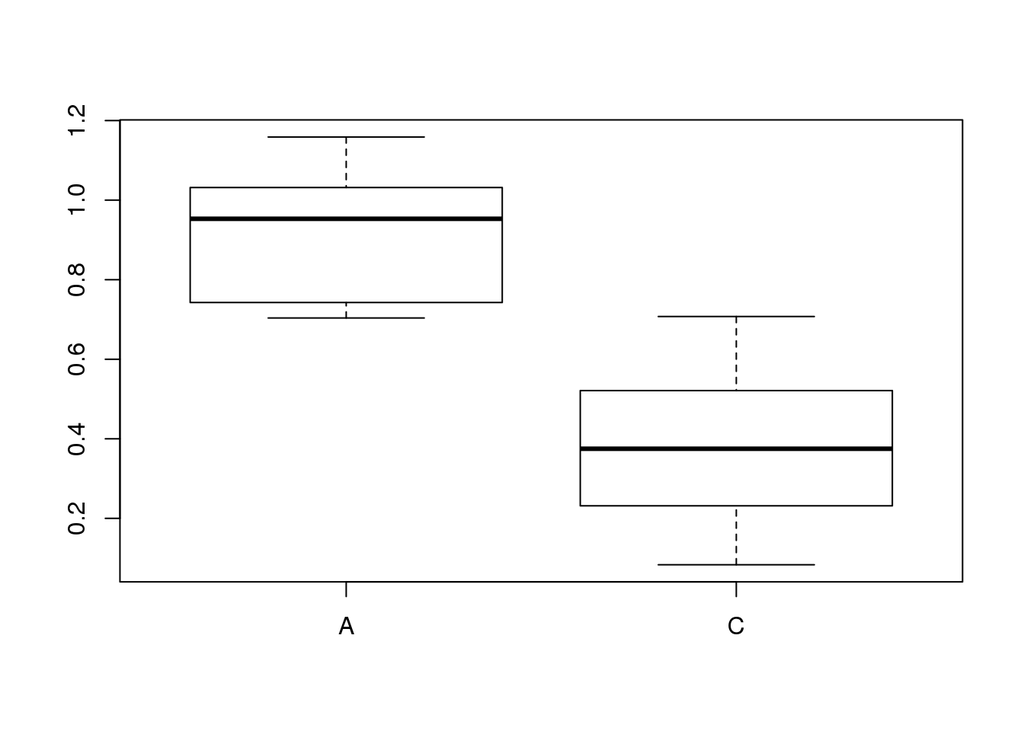

```r
boxplot(pcu_score ~ age_grp, game.wmc)
```

*pcu*score_ predicts *accuracy*, as does *age*grp_.

```r
fm.wmc <- lm(accuracy ~ pcu_score, game.wmc)
summary(fm.wmc)
```

```
##
## Call:
## lm(formula = accuracy ~ pcu_score, data = game.wmc)
##
## Residuals:
##       Min        1Q    Median        3Q       Max
## -0.138633 -0.039509 -0.006947  0.048934  0.118975
##
## Coefficients:
##             Estimate Std. Error t value Pr(>|t|)
## (Intercept)  0.64043    0.02121   30.19  < 2e-16 ***
## pcu_score    0.18454    0.03456    5.34 6.76e-06 ***
## ---
## Signif. codes:  0 '***' 0.001 '**' 0.01 '*' 0.05 '.' 0.1 ' ' 1
##
## Residual standard error: 0.06173 on 33 degrees of freedom
##   (1 observation deleted due to missingness)
## Multiple R-squared:  0.4636, Adjusted R-squared:  0.4473
## F-statistic: 28.52 on 1 and 33 DF,  p-value: 6.761e-06
```

```r
anova(fm.wmc) # ok to use type I Sum of Squares, because we have only one predictor
```

```
## Analysis of Variance Table
##
## Response: accuracy
##           Df  Sum Sq  Mean Sq F value    Pr(>F)
## pcu_score  1 0.10868 0.108677  28.517 6.761e-06 ***
## Residuals 33 0.12576 0.003811
## ---
## Signif. codes:  0 '***' 0.001 '**' 0.01 '*' 0.05 '.' 0.1 ' ' 1
```

```r
fm.age <- lm(accuracy ~ age_grp, game.wmc)
summary(fm.age)
```

```
##
## Call:
## lm(formula = accuracy ~ age_grp, data = game.wmc)
##
## Residuals:
##       Min        1Q    Median        3Q       Max
## -0.149367 -0.029189 -0.000708  0.042861  0.125874
##
## Coefficients:
##             Estimate Std. Error t value Pr(>|t|)
## (Intercept)  0.76491    0.01227  62.315  < 2e-16 ***
## age_grp1     0.05534    0.01227   4.509 7.38e-05 ***
## ---
## Signif. codes:  0 '***' 0.001 '**' 0.01 '*' 0.05 '.' 0.1 ' ' 1
##
## Residual standard error: 0.06598 on 34 degrees of freedom
## Multiple R-squared:  0.3742, Adjusted R-squared:  0.3558
## F-statistic: 20.33 on 1 and 34 DF,  p-value: 7.379e-05
```

```r
anova(fm.wmc)
```

```
## Analysis of Variance Table
##
## Response: accuracy
##           Df  Sum Sq  Mean Sq F value    Pr(>F)
## pcu_score  1 0.10868 0.108677  28.517 6.761e-06 ***
## Residuals 33 0.12576 0.003811
## ---
## Signif. codes:  0 '***' 0.001 '**' 0.01 '*' 0.05 '.' 0.1 ' ' 1
```

But if we combine both, and use type III Sum of Squares, we get perplexing result

```r
options(contrasts = c("contr.sum", "contr.poly"))
fm.axw <- lm(accuracy ~ pcu_score + age_grp, game.wmc)
summary(fm.axw)
```

```
##
## Call:
## lm(formula = accuracy ~ pcu_score + age_grp, data = game.wmc)
##
## Residuals:
##       Min        1Q    Median        3Q       Max
## -0.132234 -0.033580 -0.005478  0.051336  0.124234
##
## Coefficients:
##             Estimate Std. Error t value Pr(>|t|)
## (Intercept)  0.67400    0.04086  16.496   <2e-16 ***
## pcu_score    0.13722    0.06015   2.281   0.0293 *
## age_grp1     0.01933    0.02010   0.962   0.3434
## ---
## Signif. codes:  0 '***' 0.001 '**' 0.01 '*' 0.05 '.' 0.1 ' ' 1
##
## Residual standard error: 0.0618 on 32 degrees of freedom
##   (1 observation deleted due to missingness)
## Multiple R-squared:  0.4786, Adjusted R-squared:  0.4461
## F-statistic: 14.69 on 2 and 32 DF,  p-value: 2.98e-05
```

```r
Anova(fm.axw, type=3)
```

```
## Anova Table (Type III tests)
##
## Response: accuracy
##              Sum Sq Df  F value  Pr(>F)
## (Intercept) 1.03943  1 272.1299 < 2e-16 ***
## pcu_score   0.01988  1   5.2047 0.02932 *
## age_grp     0.00353  1   0.9251 0.34335
## Residuals   0.12223 32
## ---
## Signif. codes:  0 '***' 0.001 '**' 0.01 '*' 0.05 '.' 0.1 ' ' 1
```

In this case, you may not want to report the results of the previous F-test. Instead, you may want to either compare the two alternative models and say that they are not significantly different. Or, you can use type I Sum of Squares to investigate is there any age related variation left after controlling for the working memory capacity.

```r
anova(fm.axw)
```

```
## Analysis of Variance Table
##
## Response: accuracy
##           Df   Sum Sq  Mean Sq F value    Pr(>F)
## pcu_score  1 0.108677 0.108677 28.4526 7.516e-06 ***
## age_grp    1 0.003533 0.003533  0.9251    0.3434
## Residuals 32 0.122227 0.003820
## ---
## Signif. codes:  0 '***' 0.001 '**' 0.01 '*' 0.05 '.' 0.1 ' ' 1
```